# pr_1

ori oberman - 311227995 | אביעד דון 311586986

31 3 2022

```r
## Set directory
path <- "C:/Users/osoor/Documents/eco/ML_EC"
setwd(path)
getwd()
```

```
## [1] "C:/Users/osoor/Documents/eco/ML_EC"
```

```r
options(scipen = 999)
```

# Linear Regression Analysis

## 2

```r
df <- fread("CAhousing.csv")
```

## 3

### a

```r
df %>% fdim()
```

```
## [1] 20640     9
```

### b

```r
df %>% qsu()
```

```
##                       N        Mean          SD      Min      Max
## longitude         20640   -119.5697      2.0035  -124.35  -114.31
## latitude          20640     35.6319       2.136    32.54    41.95
## housingMedianAge  20640     28.6395     12.5856        1       52
## totalRooms        20640   2635.7631   2181.6153        2    39320
## totalBedrooms     20640     537.898    421.2479        1     6445
## population        20640   1425.4767   1132.4621        3    35682
## households        20640    499.5397    382.3298        1     6082
## medianIncome      20640      3.8707      1.8998   0.4999  15.0001
## medianHouseValue  20640  206855.817  115395.616    14999   500001
```

```r
df %>% descr
```

```
## Dataset: ., 9 Variables, N = 20640
## --------------------------------------------------------------------------------
## longitude (numeric):
## Stats:
##       N  Ndist     Mean  SD      Min      Max  Skew  Kurt
##   20640    844  -119.57   2  -124.35  -114.31  -0.3  1.67
## Quant:
##        1%       5%     25%      50%      75%      95%      99%
##   -123.22  -122.47  -121.8  -118.49  -118.01  -117.08  -116.29
## --------------------------------------------------------------------------------
## latitude (numeric):
## Stats:
##       N  Ndist   Mean    SD    Min    Max  Skew  Kurt
##   20640    862  35.63  2.14  32.54  41.95  0.47  1.88
## Quant:
##      1%     5%    25%    50%    75%    95%    99%
##   32.68  32.82  33.93  34.26  37.71  38.96  40.63
## --------------------------------------------------------------------------------
## housingMedianAge (numeric):
## Stats:
##       N  Ndist   Mean     SD  Min  Max  Skew  Kurt
##   20640     52  28.64  12.59    1   52  0.06   2.2
## Quant:
##   1%  5%  25%  50%  75%  95%  99%
##    4   8   18   29   37   52   52
## --------------------------------------------------------------------------------
## totalRooms (numeric):
## Stats:
##       N  Ndist     Mean       SD  Min    Max  Skew   Kurt
##   20640   5926  2635.76  2181.62    2  39320  4.15  35.62
## Quant:
##    1%      5%      25%   50%   75%     95%       99%
##   164  620.95  1447.75  2127  3148  6213.2  11212.11
## --------------------------------------------------------------------------------
## totalBedrooms (numeric):
## Stats:
##       N  Ndist   Mean      SD  Min   Max  Skew   Kurt
##   20640   1928  537.9  421.25    1  6445  3.45  24.92
## Quant:
##      1%   5%  25%  50%  75%      95%      99%
```

[output cut: 19 more lines]

```
## Stats:
##       N  Ndist  Mean   SD  Min  Max  Skew  Kurt
##   20640  12928  3.87  1.9  0.5   15  1.65  7.95
## Quant:
##     1%   5%   25%   50%   75%  95%   99%
##   1.07  1.6  2.56  3.53  4.74  7.3  10.6
## --------------------------------------------------------------------------------
## medianHouseValue (numeric):
## Stats:
##       N  Ndist       Mean         SD    Min     Max  Skew  Kurt
##   20640   3842  206855.82  115395.62  14999  500001  0.98  3.33
## Quant:
##      1%     5%     25%     50%     75%     95%     99%
##   50000  66200  119600  179700  264725  489810  500001
## --------------------------------------------------------------------------------
```

יתכן ונין לדבר על ערכים חריגים בקצוות במשתנה של מספר החדרים וכן במשתנה כמות הדירות בבלוק. אולם בהצגה זו לא ניתן להבחין באופן נוח בחריגים. שכן חריגות איננה רק מדד שיש יחס בתוך במשתנה אלא גם היחס בין משתנה למשתנים אחרים.

### d

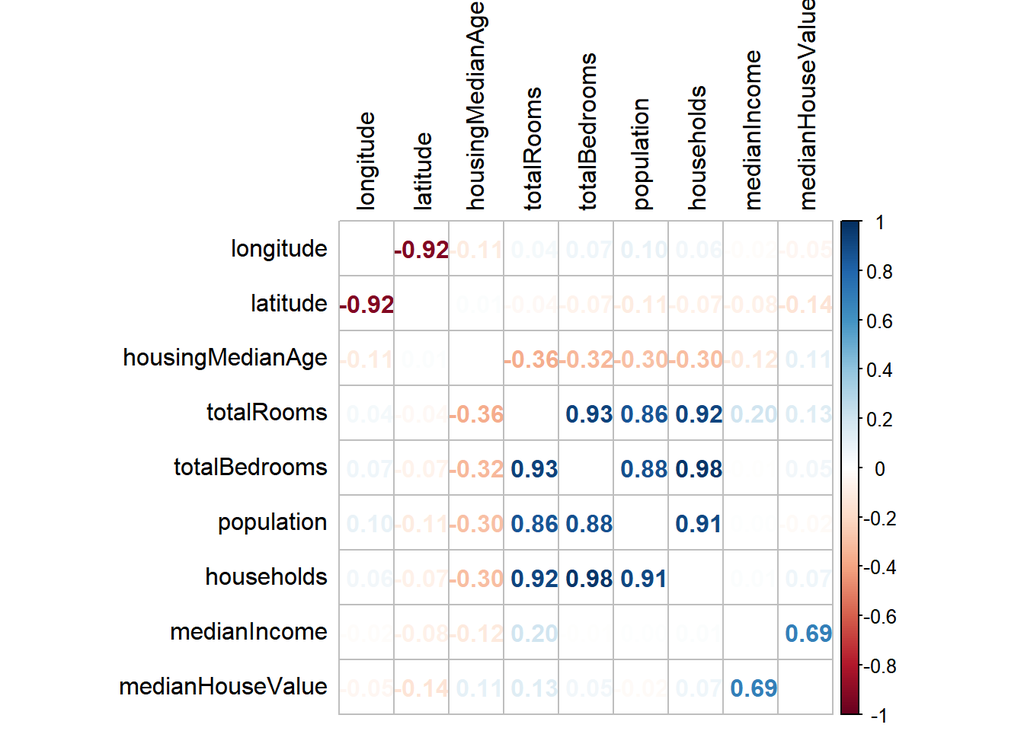

```r
df %>% cor() %>% corrplot(method = 'number',diag = FALSE, tl.col = "black")
```

אנו ראים מתאם גבוה בין מדדי החדרים השונים וכן בין מדד גודל האוכלוסיה למדדי החדרים ובנוסף מתאים גבוה בין מדדי ההכנסה לערך הבית ומתאם בין הקורדינטות

## 4

### a

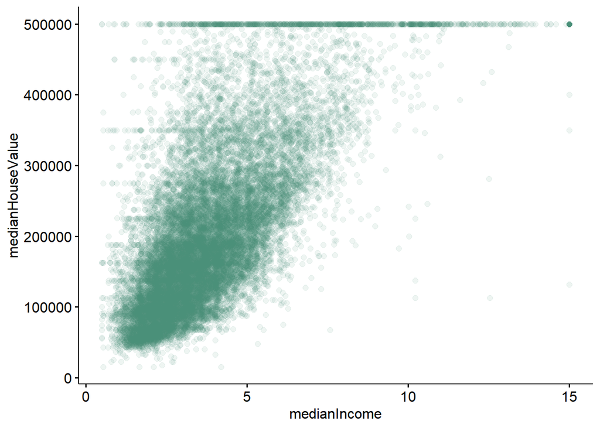

```r
df %>%  ggscatter(x= "medianIncome",y="medianHouseValue",color = alpha(c("#458B74"),0.09),fill =alpha(c("#458B74"),0.04))
```

אנו רואים שכאשר החציון של ערך הבתים גובה אין מתאם עם ההשתכרות החצונית של תושבי הבלוק. אולם בערכים נמוכים יותר נראה שישנה מגמה כלילת על מתאם חיובי

### b

```r
reg_1 <- df %>%   lm(medianHouseValue ~ medianIncome,data = .)
```

### c

```r
reg_1 %>% summary
```

```
##
## Call:
## lm(formula = medianHouseValue ~ medianIncome, data = .)
##
## Residuals:
##     Min      1Q  Median      3Q     Max
## -540697  -55950  -16979   36978  434023
##
## Coefficients:
##              Estimate Std. Error t value            Pr(>|t|)
## (Intercept)   45085.6     1322.9   34.08 <0.0000000000000002 ***
## medianIncome  41793.8      306.8  136.22 <0.0000000000000002 ***
## ---
## Signif. codes:  0 '***' 0.001 '**' 0.01 '*' 0.05 '.' 0.1 ' ' 1
##
## Residual standard error: 83740 on 20638 degrees of freedom
## Multiple R-squared:  0.4734, Adjusted R-squared:  0.4734
## F-statistic: 1.856e+04 on 1 and 20638 DF,  p-value: < 0.00000000000000022
```

### d

המודל הנאמד מנסח קשר לינארי בין ערכו החציוני של בית בבלוק ובין השכר החציוני של תושבי הבלוק.

במודל זה החותך מייצג את ערכה של דירה באופן בסיסי, ללא קושר למעמד הכלכלי של תושבי הבלוק.

האומד במודל מיצג את העליה של ערך הדירה כיחס של עליה בשכר החצוני בגודל של עשרת אלפים דולר .

גם החותך וגם האמוד נמצאו במובהקים.

כן כל המודל.

אחוז השונות המוסברת על ידי מודל זה הינה 47 אחוז

### e

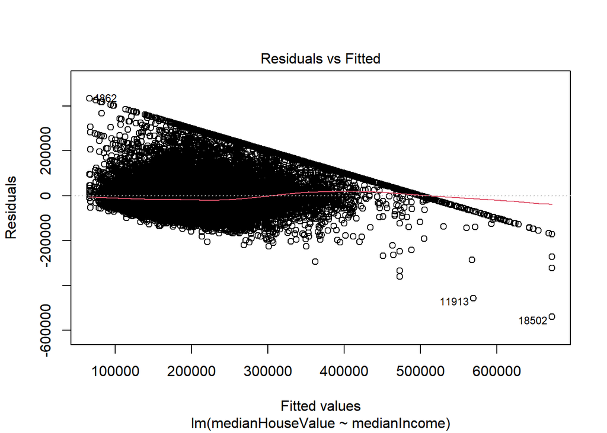

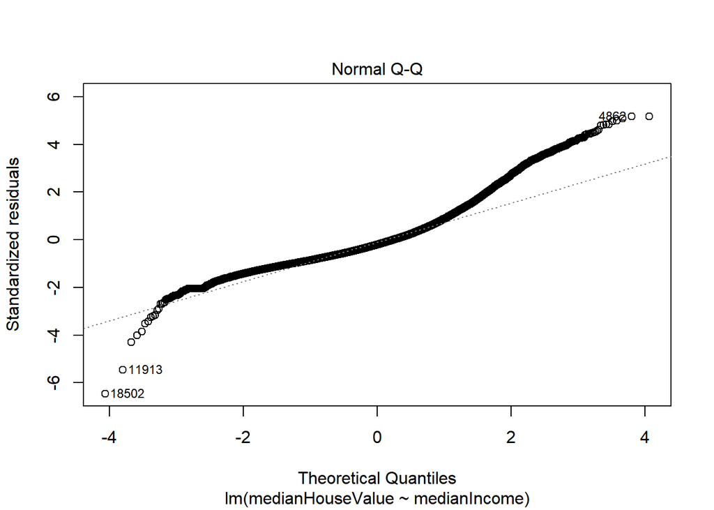

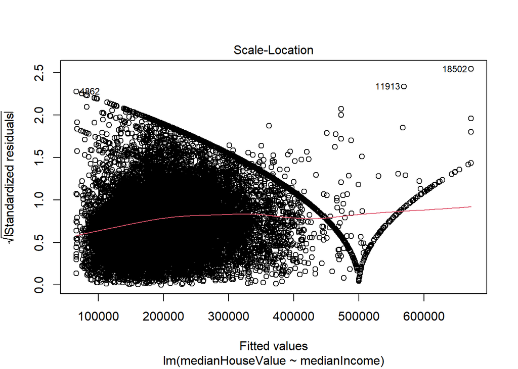

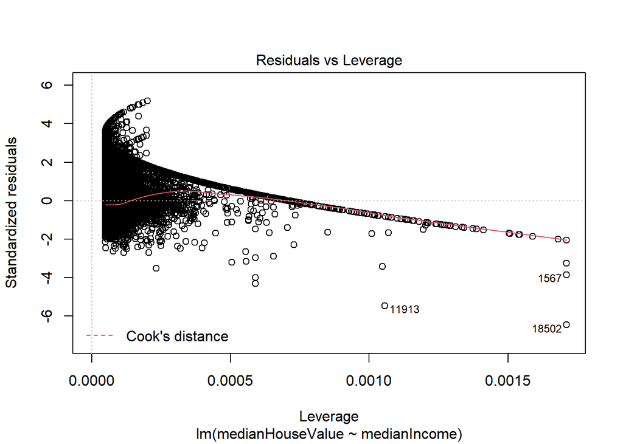

```r
reg_1 %>% plot()
```

### f

```r
reg_1_pr<- reg_1 %>% predict()
```

### g

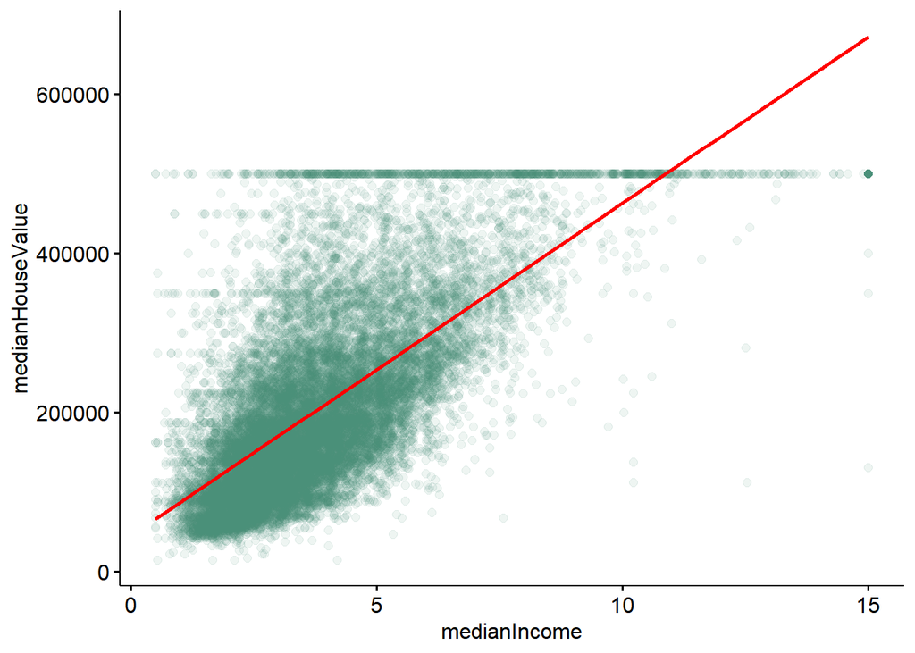

```r
df %>%  ggscatter(x= "medianIncome",y="medianHouseValue",add="reg.line",add.params=list(color = "red"),color = alpha(c("#458B74"),0.09),fill =alpha(c("#458B74"),0.01) )
```

נראה שהמודל אינו מספק חיזוי טוב. השונות הגדולה בהכנסה החציונית במקרה של ערכי בדירות גובהים מטה את השיפוע של האומד. כתוצאה מכך גם באזורים בהם השונות נמוכה יותר המודל בעל טעויות גדולות ואינו מציגת את המגמה שמצויה ביחס שבין הכנסה לערך הבית.

## 5

### a

אנו רואים שיש ערכים קוצוניים. בניהם ניתן להבחין שבעלויות גבוהות אין מתאם בין השכר ההחציוני לערך הדירה החציוני

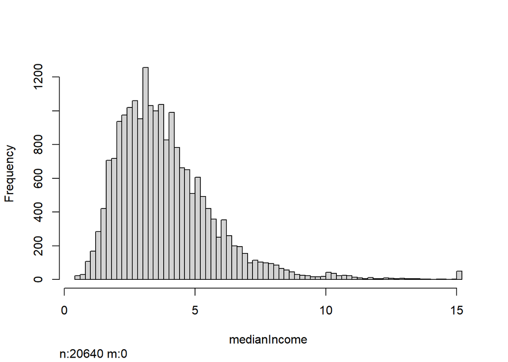

```r
hist(df[,.(medianIncome)], breaks=100)
```

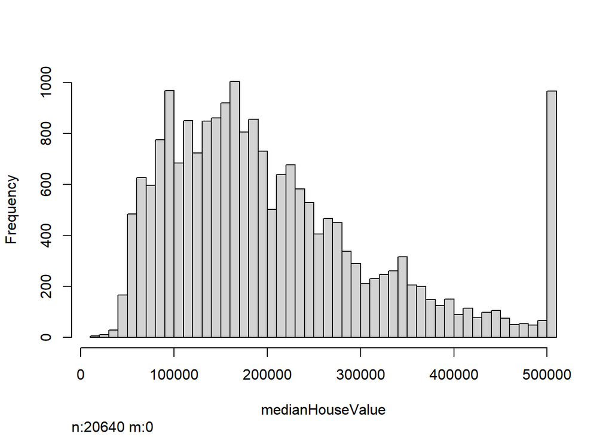

```r
hist(df[,.(medianHouseValue)], breaks=100)
```

ניתן לראות שישנה הבדל גדול בהתפלגות. בעוד שההכנסה החציונית מתפלגת באופן יחסת אחיד עם זנב בערכים הגובהים. לעומת זאת אנו רואים הצטברות גבוהה בערכים הגבוהים

### b

```r
reg_2 <- lm(medianHouseValue~.,data =df)

reg_2  %>% summary
```

```
##
## Call:
## lm(formula = medianHouseValue ~ ., data = df)
##
## Residuals:
##     Min      1Q  Median      3Q     Max
## -563013  -43592  -11327   30307  803996
##
## Coefficients:
##                       Estimate    Std. Error t value             Pr(>|t|)
## (Intercept)      -3594022.9419    62539.3855 -57.468 < 0.0000000000000002 ***
## longitude          -42823.7438      713.0082 -60.061 < 0.0000000000000002 ***
## latitude           -42576.7219      673.2571 -63.240 < 0.0000000000000002 ***
## housingMedianAge     1156.3039       43.1672  26.787 < 0.0000000000000002 ***
## totalRooms             -8.1816        0.7881 -10.381 < 0.0000000000000002 ***
## totalBedrooms         113.4107        6.9019  16.432 < 0.0000000000000002 ***
## population            -38.5351        1.0789 -35.716 < 0.0000000000000002 ***
## households             48.3083        7.5146   6.429       0.000000000132 ***
## medianIncome        40248.5142      335.0598 120.123 < 0.0000000000000002 ***
## ---
## Signif. codes:  0 '***' 0.001 '**' 0.01 '*' 0.05 '.' 0.1 ' ' 1
##
## Residual standard error: 69530 on 20631 degrees of freedom
## Multiple R-squared:  0.6371, Adjusted R-squared:  0.637
## F-statistic:  4528 on 8 and 20631 DF,  p-value: < 0.00000000000000022
```

### c

נראה שהמודל המלא שהוצע בעייתי, נראה שהכללת הקורדינטות כמשתנה מסביר באופן הזה אינה הגיונית. ברור שלמיקום הוא בעל השפעה על ערך הדירה, אולם נראה שהשפעת המיקום אינה תוצאה של קרבה לקו המשווה או מרחק מהקטבים. כך שהכנסתם כגורם הסברי באופן לינארי נראת לכל הפחות תמוהה.

יתר על כן, מכיוון שערכי האומדים של קו האורך וקו הגובה כמעט זהים והקולרציה שלהם קרובה לאיחד ושלילית שני עומדים למעשה יבטלו האחד את השני. על פניו נראה שיותר הגיוני להתיחס למיקום כמשתנה דמי של צמדי קורדינטות ולא כמשתנה כמותי

עניין נוסף הוא היחס בין המדד של המשתנה המוסבר למשתנים המסברים. המדד המוסבר הוא מדד בעבור דירה. אולם חלק מן המדדים אינם כאלו ומציינים כמויות כלליות בעבור הבלוק. למשל אוכלוסיה, כמות חדרי השינה, וכמות החדרים הכללית. נראה שעדיף להחליף את המשתנים הללו במשתנים המייצגים מדד פר דירה. באופן זה נרווח דבר נוסף.נבטל את המתאם החזק הקיים בין המשתנה האוכליסה למשתני החדרים.

כפי שניתן לראות להלן:

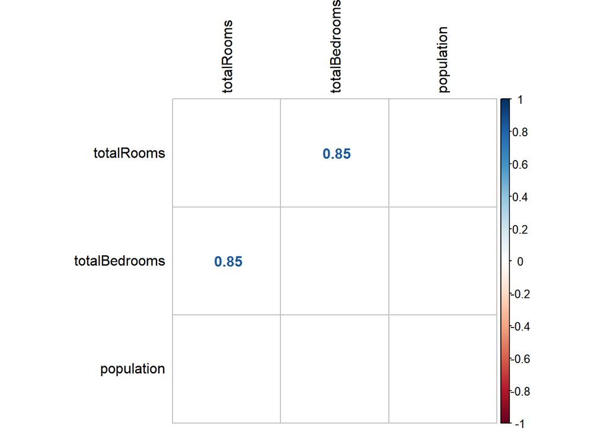

```r
(df[,.(totalRooms,totalBedrooms,population)]/df$households) %>% cor() %>% corrplot(method = 'number',diag = FALSE, tl.col = "black")
```

# KNN

## 1

החבילה נטענה כבר בתחילת התרגיל

## 2

```r
dat  <-   Default %>% qDT
```

## 3

### a

```r
dat %>% fdim
```

```
## [1] 10000     4
```

### b

```r
dat %>% descr()
```

```
## Dataset: ., 4 Variables, N = 10000
## --------------------------------------------------------------------------------
## default (factor):
## Stats:
##       N  Ndist
##   10000      2
## Table:
##      Freq   Perc
## No   9667  96.67
## Yes   333   3.33
## --------------------------------------------------------------------------------
## student (factor):
## Stats:
##       N  Ndist
##   10000      2
## Table:
##      Freq   Perc
## No   7056  70.56
## Yes  2944  29.44
## --------------------------------------------------------------------------------
## balance (numeric):
## Stats:
##       N  Ndist    Mean      SD  Min      Max  Skew  Kurt
##   10000   9502  835.37  483.71    0  2654.32  0.25  2.64
## Quant:
##   1%    5%     25%     50%      75%      95%      99%
##    0  0.42  481.73  823.64  1166.31  1665.96  2008.47
## --------------------------------------------------------------------------------
## income (numeric):
## Stats:
##       N  Ndist      Mean        SD     Min       Max  Skew  Kurt
##   10000  10000  33516.98  13336.64  771.97  73554.23  0.07   2.1
## Quant:
##        1%        5%       25%       50%       75%       95%       99%
##   9801.37  13431.77  21340.46  34552.64  43807.73  54677.89  61656.74
## --------------------------------------------------------------------------------
```

### c

```r
?Default
```

```
## starting httpd help server ... done
```

### d

```r
num_names <- dat %>% num_vars() %>% names()

 dat[,lapply(.SD, sd),.SDcols = num_names] %>% print()
```

```
##    balance   income
## 1: 483.715 13336.64
```

הערכים אינם מנורמלים, סטיית התקן אינה שווה ל1

## 4

### a

```r
dat %<>% .[, -c("student")]
```

### b

```r
dat[,paste(num_names):= lapply(.SD,fscale),.SDcols= num_names]
```

### c

```r
library(rsample)

dat_split <- rsample::initial_split(dat)

train_dat <- training(dat_split)
test_dat <- testing(dat_split)
```

### d

```r
KNN_LOOP<- foreach(k_n=c(1,5,20,70)) %do% {

  # c

step_1 <-   knn(train = train_dat[,2:3],test = test_dat[,2:3],k = k_n,cl =train_dat$default )

assign(paste0("rknn_",k_n),step_1)

# d
# ליצור טבלת שיכחות

assign(paste0("tknn_",k_n),table(get(paste0("rknn_",k_n))))

# e
# ליצור טבלת הסתברות

assign(paste0("pknn_",k_n),prop.table(get(paste0("tknn_",k_n))))



}
```

נראה דוגמאות לכך שהתהליך עבד

```r
rknn_20 %>% head()
```

```
## [1] No No No No No No
## Levels: No Yes
```

```r
tknn_20
```

```
##
##   No  Yes
## 2453   47
```

```r
pknn_20
```

```
##
##     No    Yes
## 0.9812 0.0188
```

## 5

```r
tab_train <- train_dat$default %>% table()

prop_train <- prop.table(tab_train)
tab_train
```

```
## .
##   No  Yes
## 7256  244
```

```r
prop_train
```

```
## .
##         No        Yes
## 0.96746667 0.03253333
```

ליצור מספר רב של K ולבדוק מה ההסתברות שתתקבל אנו ננסה למעזר את הטעות ולבחור את הK שיתן את הטעות המינימלית.

```r
tab_test <- test_dat$default %>% table()

prop_test <- prop.table(tab_test)

p_knn_list <- ls(pattern = "pknn_")

 foreach(p=p_knn_list,.combine = `rbind`)%do% {
  prop_test-get(p)
} %>% `row.names<-`(.,p_knn_list)
```

```
##              No     Yes
## pknn_1   0.0020 -0.0020
## pknn_20 -0.0168  0.0168
## pknn_5  -0.0156  0.0156
## pknn_70 -0.0240  0.0240
```

# Kernel Regression

## 1

```r
df_1 <- df %>% num_vars() %>% fscale()


df_split <- rsample::initial_split(df_1,prop = 4/5)

train_df <- training(df_split) %>% .[order(medianIncome)]
test_df <- testing(df_split) %>% .[order(medianIncome)]
```

### a

החבילה טעונה כבר באופן אוטומטי

### b + c

```r
# יצירה של משתנים בשביל הלולאה


kernel_type <-  c("box", "normal")

type_df <- c("train_df" , "test_df")

# מתן אפשרות לשימוש במספר של ליבות מעבד

cl <- makePSOCKcluster(4)
doParallel::registerDoParallel(cl)


ks_df <-
  foreach(kernel_type = kernel_type ,.combine = 'rbind') %:%
  foreach(h_n = 1:20/10,.combine = 'rbind' )%:%
  foreach(type_df = type_df,.combine = 'rbind',.packages = c("fastverse" ,"stringr") ,.export = type_df) %dopar% {

# הפעלת הפונקציה ויצוא שלה כדטא טייבול
    df_step1 <-
      ksmooth(
        x = get(type_df)$medianIncome, # המשתנה המסביר
        y = get(type_df)$medianHouseValue, # המשתנה המוסבר
        kernel_type,# שיטת הקצאת המשקולות
        bandwidth = h_n, # האיזון למרחק
        x.points = unique(get(type_df)$medianIncome) # משתנים מסברים שלהם מתקבש למצוא חיזוי
      ) %>% qDT()

# צימוד לערכי המשתנים המוסברים האמיתיים
    df_step1 <-
      merge.data.table(
        df_step1,
        get(type_df)[, .(medianHouseValue, medianIncome)],
        by.x = "x",
        by.y = "medianIncome" ,
        all.y = TRUE
      )
# יצירת משתני זיהוי בשביל בשביל הטבלה

    df_step1[, "kernel" := kernel_type]

    df_step1[, "h" := h_n]

    df_step1[, "kind" := str_sub(type_df, end = -4)]

    df_step1[, true_y := medianHouseValue]

    df_step1[, medianHouseValue := NULL]


    df_step1

}

# להראות תוצרים של התהליך

ks_df %>% head() %>% print()
```

```
##            x          y kernel   h  kind     true_y
## 1: -1.774256 -0.3815881    box 0.1 train -1.0074544
## 2: -1.774256 -0.3815881    box 0.1 train -1.2076353
## 3: -1.774256 -0.3815881    box 0.1 train -0.3843804
## 4: -1.774256 -0.3815881    box 0.1 train -0.3843804
## 5: -1.774256 -0.3815881    box 0.1 train -1.1556402
## 6: -1.774256 -0.3815881    box 0.1 train  2.5403494
```

לוודא שהלולאה עבדה ולאיקסים צומד הווי המקורי שלהם

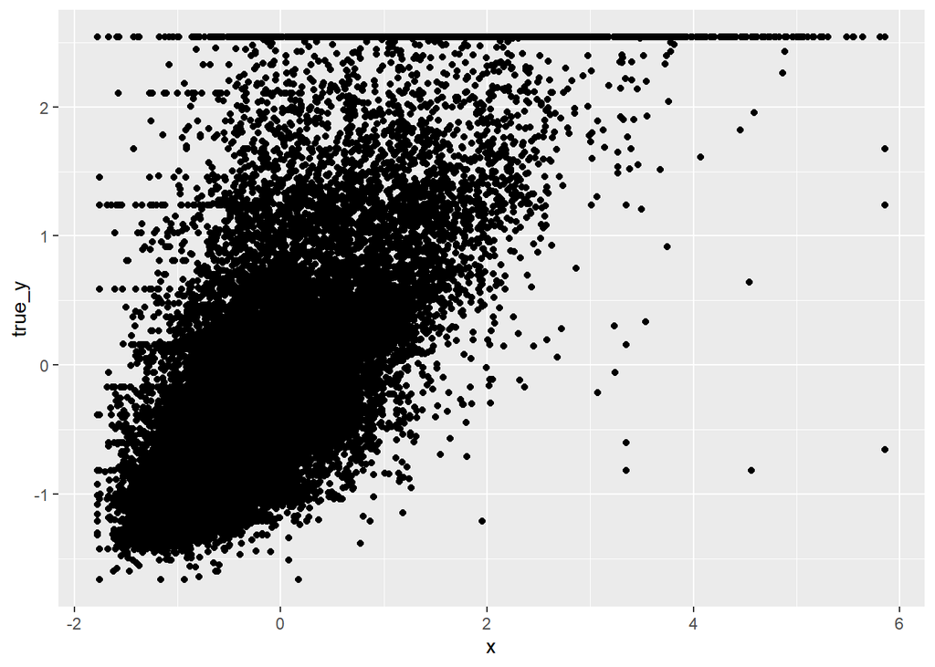

```r
# לבדוק שהיחס בין המשתנה המסביר נתון האמיתי זהה לנתוני המקור

qplot(data=ks_df,x=x,y = true_y)
```

### d

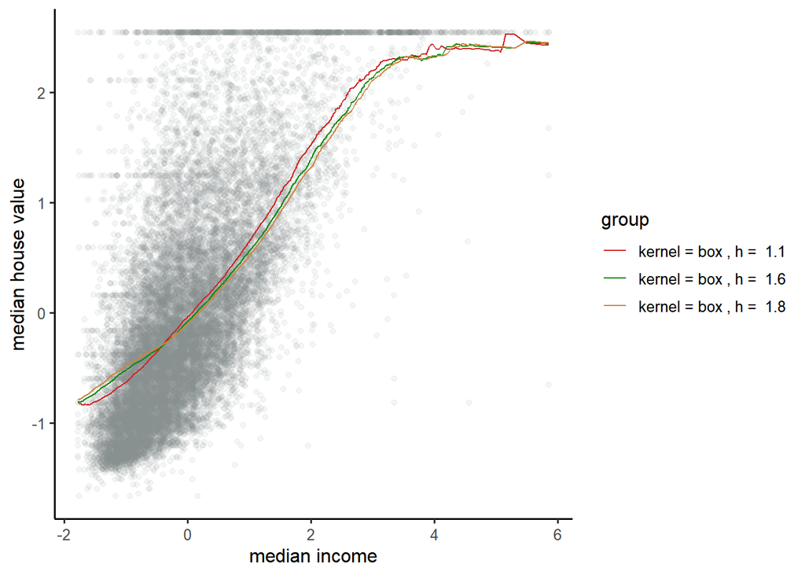

```r
df_plot_ks<- ks_df[kind == "train"][,group := paste("kernel =",kernel,",","h = ",h ),by=.(kernel,h)]

set.seed(1244)

sam <- sample(1:20,3)

gro_sam<- df_plot_ks$group %>% unique() %>% .[sam]

df_plot_ks[group %in% gro_sam] %>% ggplot() +
  geom_point(
    aes(x = x, y = true_y),
    color = alpha(c("#838B8B"), 0.09),
    fill = alpha(c("#838B8B"), 0.04),
    data = funique(ks_df[, .(x, true_y)]),
    inherit.aes = TRUE
  ) +
  geom_line(aes(x = x, y = y, color = group), inherit.aes = FALSE) +
  color_palette(c("#CD2626", "#008B00", "#CD853F")) +
  xlab("median income")+
  ylab("median house value")+
  theme_classic2()
```

### e

```r
ks_df[, kind_MSE := paste0(kind, "_mse")]
```

```r
ks_df[, .(mse = fmean((y - true_y)^2)), by = .(kernel, h, kind_MSE)] %>%
  dcast(kernel + h ~ kind_MSE, value.var = "mse") %>%
  flextable()
```

| kernel | h | test_mse | train_mse |
| --- | --- | --- | --- |
| box | 0.1 | 0.5095217 | 0.5061395 |
| box | 0.2 | 0.5133706 | 0.5078130 |
| box | 0.3 | 0.5139139 | 0.5080244 |
| box | 0.4 | 0.5155833 | 0.5083986 |
| box | 0.5 | 0.5157697 | 0.5085163 |
| box | 0.6 | 0.5162284 | 0.5090417 |
| box | 0.7 | 0.5174141 | 0.5097503 |
| box | 0.8 | 0.5182984 | 0.5105622 |
| box | 0.9 | 0.5195847 | 0.5117648 |
| box | 1.0 | 0.5209446 | 0.5132633 |
| box | 1.1 | 0.5222017 | 0.5151088 |
| box | 1.2 | 0.5243102 | 0.5174348 |
| box | 1.3 | 0.5266289 | 0.5200870 |
| box | 1.4 | 0.5295306 | 0.5231574 |
| box | 1.5 | 0.5327247 | 0.5267882 |
| box | 1.6 | 0.5362906 | 0.5307801 |
| box | 1.7 | 0.5407599 | 0.5353590 |
| box | 1.8 | 0.5456576 | 0.5402879 |
| box | 1.9 | 0.5512727 | 0.5456523 |
| box | 2.0 | 0.5570859 | 0.5513352 |
| normal | 0.1 | 0.5086181 | 0.5055528 |
| normal | 0.2 | 0.5124347 | 0.5072033 |
| normal | 0.3 | 0.5139143 | 0.5078285 |
| normal | 0.4 | 0.5149605 | 0.5083584 |
| normal | 0.5 | 0.5159771 | 0.5090250 |
| normal | 0.6 | 0.5170888 | 0.5099451 |
| normal | 0.7 | 0.5184093 | 0.5112069 |
| normal | 0.8 | 0.5200575 | 0.5128869 |
| normal | 0.9 | 0.5221376 | 0.5150473 |
| normal | 1.0 | 0.5247202 | 0.5177351 |
| normal | 1.1 | 0.5278520 | 0.5209810 |
| normal | 1.2 | 0.5315562 | 0.5248024 |
| normal | 1.3 | 0.5358429 | 0.5292050 |
| normal | 1.4 | 0.5407097 | 0.5341837 |
| normal | 1.5 | 0.5461423 | 0.5397234 |
| normal | 1.6 | 0.5521176 | 0.5458006 |
| normal | 1.7 | 0.5586045 | 0.5523835 |
| normal | 1.8 | 0.5655668 | 0.5594337 |
| normal | 1.9 | 0.5729626 | 0.5669079 |
| normal | 2.0 | 0.5807472 | 0.5747588 |

### f

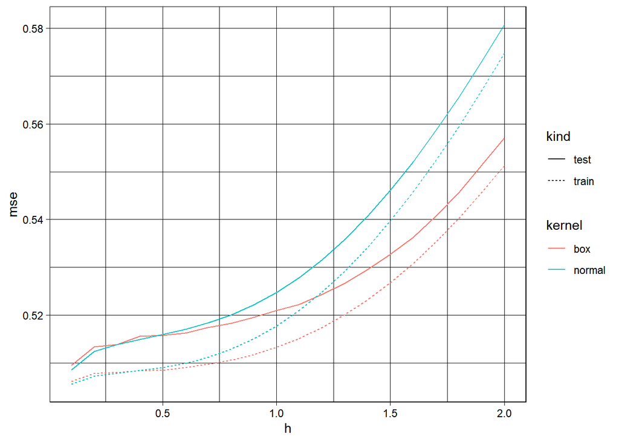

```r
ks_df[, .(mse = fmean((y - true_y)^2)), by = .(kernel, h, kind)] %>%
  ggplot(aes(x = h, y = mse)) +
  geom_line(aes(linetype = kind, color = kernel)) +
  theme_linedraw()
```

נראה שמודל הבוקס יציב יותר כאשר מגדילים את הקנס למרחק. אולם כאמור, כפי שצויין בהערה אנו הרצנו את הפער בין הנתונים לבין עצמם כך שקשה לשפוט במקרה זה.

### g

כפי שאמרתי למעלה. אני באמת לא יודע כלכך להגיד. צריך לראות את ההתנהגות ביחס לנתונים אחרים.

לצורך הבדיקה ננסה להריץ את הפרוצדורה שוב כאשר הפעם האיקסים שנתבקש לחזות יהיו האיקסים מקובץ המבחן

```r
ks_df_2 <-
  foreach(kernel_type = kernel_type ,.combine = 'rbind') %:%
  foreach(h_n = 1:20/10,.combine = 'rbind' ,.packages = c("fastverse" ,"stringr") ,.export = type_df) %dopar% {

# הפעלת הפונקציה ויצוא שלה כדטא טייבול
    df_step1 <-
      ksmooth(
        x = train_df$medianIncome, # המשתנה המסביר
        y = train_df$medianHouseValue, # המשתנה המוסבר
        kernel_type,# שיטת הקצאת המשקולות
        bandwidth = h_n, # האיזון למרחק
        x.points = unique(test_df$medianIncome) # המשתנים המסברים בקובץ ההבדיקה

      ) %>% qDT()

# צימוד לערכי המשתנים המוסברים בקובץ הבדיקה
    df_step1 <-
      merge.data.table(
        df_step1,
        test_df[, .(medianHouseValue, medianIncome)],
        by.x = "x",
        by.y = "medianIncome" ,
        all.y = TRUE
      )
# יצירת משתני זיהוי בשביל בשביל הטבלה

    df_step1[, "kernel" := kernel_type]

    df_step1[, "h" := h_n]


    df_step1[, true_y := medianHouseValue]

    df_step1[, medianHouseValue := NULL]


    df_step1

}
# להראות תוצרים של התהליך

ks_df_2 %>% head() %>% print()
```

```
##            x          y kernel   h     true_y
## 1: -1.774256 -0.3815881    box 0.1 -0.9259955
## 2: -1.774256 -0.3815881    box 0.1  2.5403494
## 3: -1.774256 -0.3815881    box 0.1 -1.3159583
## 4: -1.774256 -0.3815881    box 0.1 -1.0776477
## 5: -1.774256 -0.3815881    box 0.1 -1.3012264
## 6: -1.680774 -0.5306883    box 0.1  1.2404647
```

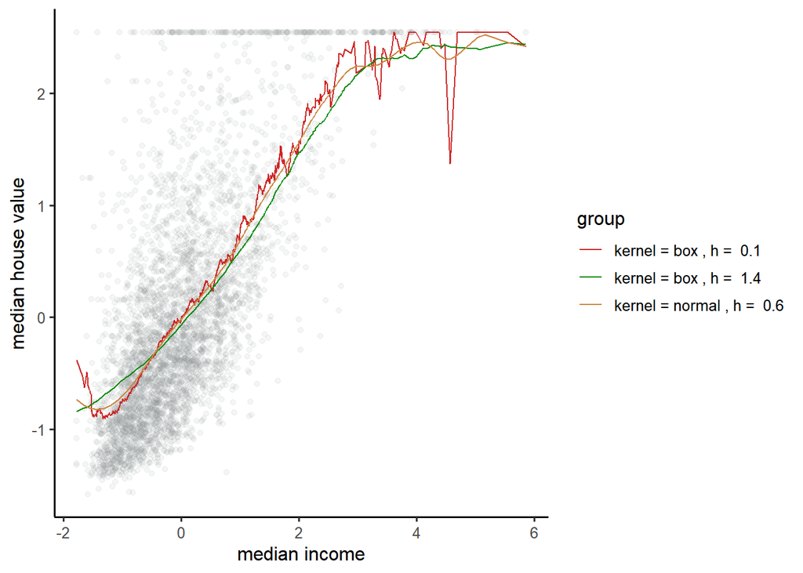

```r
df_plot_ks_2<- ks_df_2[,group := paste("kernel =",kernel,",","h = ",h ),by=.(kernel,h)]

set.seed(1244)

sam <- sample(1:40,3)


gro_sam<- df_plot_ks_2$group %>% unique() %>% .[sam]

df_plot_ks_2[group %in% gro_sam] %>% ggplot() +
  geom_point(
    aes(x = x, y = true_y),
    color = alpha(c("#838B8B"), 0.09),
    fill = alpha(c("#838B8B"), 0.04),
    data = funique(ks_df_2[, .(x, true_y)]),
    inherit.aes = TRUE
  ) +
  geom_line(aes(x = x, y = y, color = group), inherit.aes = FALSE) +
  color_palette(c("#CD2626", "#008B00", "#CD853F")) +
  xlab("median income")+
  ylab("median house value")+
  theme_classic2()
```

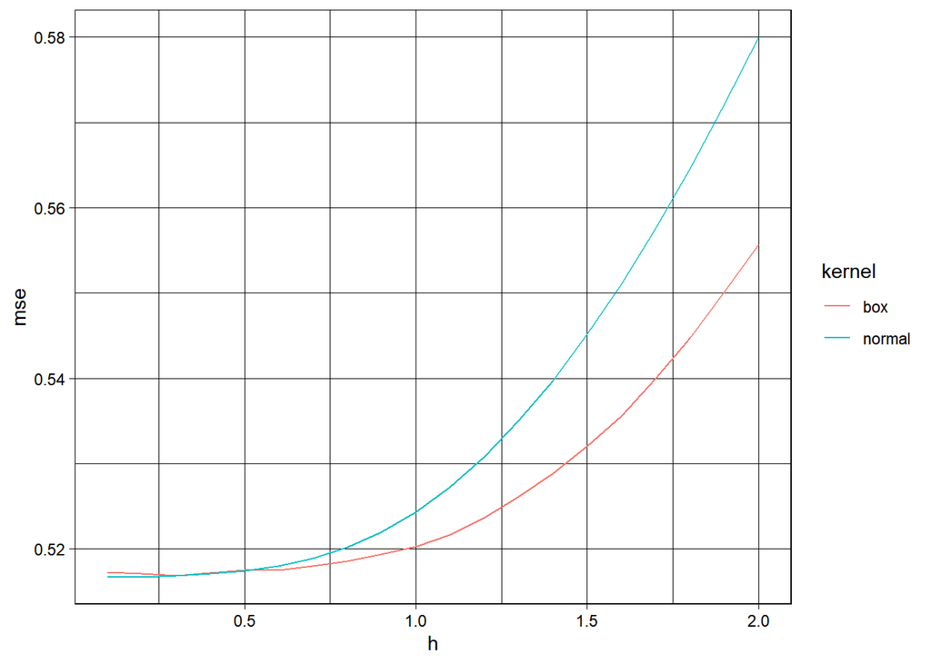

```r
ks_df_2[, .(mse = fmean((y - true_y)^2)), by = .(kernel, h)] %>%
  ggplot(aes(x = h, y = mse)) +
  geom_line(aes( color = kernel)) +
  theme_linedraw()
```

נראה שעדיף לבחור במודל הבוקס. שכן הוא הוא מייצר טעות קטנה יותר גם כאשר מגדלים את הקנס למרחק